# 2026-01-08_EOY_summary

Jess Vera

Start date: 2026-01-08  
Last updated: 2026-01-09 09:45:24.128378

# Goal

make a few simple graphs to viz growth in DUC access requests since portal inception.

# Setup

```r
# source rmarkdown_setup.R
source("~/Setup/rmarkdown_setup.R")

# Load libraries silently
suppressPackageStartupMessages({
  library(dplyr)
  library(stringr)
  library(ggplot2)
  library(lubridate)
  library(glue)
})
```

# Main

plot number of distinct requests received each year

```r
fid <- "../all_approved_requests.csv"
all_approved <- read.csv(fid, check.names = FALSE)
distinct_approved <- group_by(all_approved, `Project Lead`, Institution) %>%
  tidyr::nest()
df <- purrr::map(distinct_approved$data, function(df) {
  df <- df %>%
    arrange(year) %>%
    slice(1)
  return(df)
})
df <- bind_rows(df)
distinct_approved <- bind_cols(distinct_approved, df)

by_year <- group_by(distinct_approved, year) %>% summarise(count = n())
by_year <- filter(by_year, year != 2026)
by_year$year <- factor(as.character(by_year$year))

p <- ggplot(by_year, aes(x = year, y = count, group = 1)) +
  geom_point() + geom_line() + theme_minimal() +
  theme(text = element_text(size = 10),
        axis.text.x = element_text(angle = 45, vjust = 1, hjust = 1, size = 10),
        title = element_text(size = 10)) +
  ylim(0, max(by_year$count) + 10) +
  labs(title = "New ARK Portal Approved Access Requests",
       subtitle = "excludes renewed DUC events")
fid <- glue("{fid.prefix}.new_by_year.png")
png(fid, width = 1000, height = 800, res = 250)
print(p)
invisible(dev.off())

YoY <- purrr::map(c("2024", "2025"), function(yr, df) {
  n1 <- filter(df, year == as.numeric(yr))$count
  n0 <- filter(df, year == as.numeric(yr) - 1)$count
  yoy <- round((n1 - n0) / n0 * 100, 1)
  return(glue("{yoy}%"))
}, df = by_year)
by_year$YoY <- c(NA, YoY)
my_kable_table(by_year, cap = "New Approved Access Requests by Year")
```

New Approved Access Requests by Year

| year | count | YoY |
| --- | --- | --- |
| 2023 | 12 | NA |
| 2024 | 59 | 391.7% |
| 2025 | 106 | 79.7% |

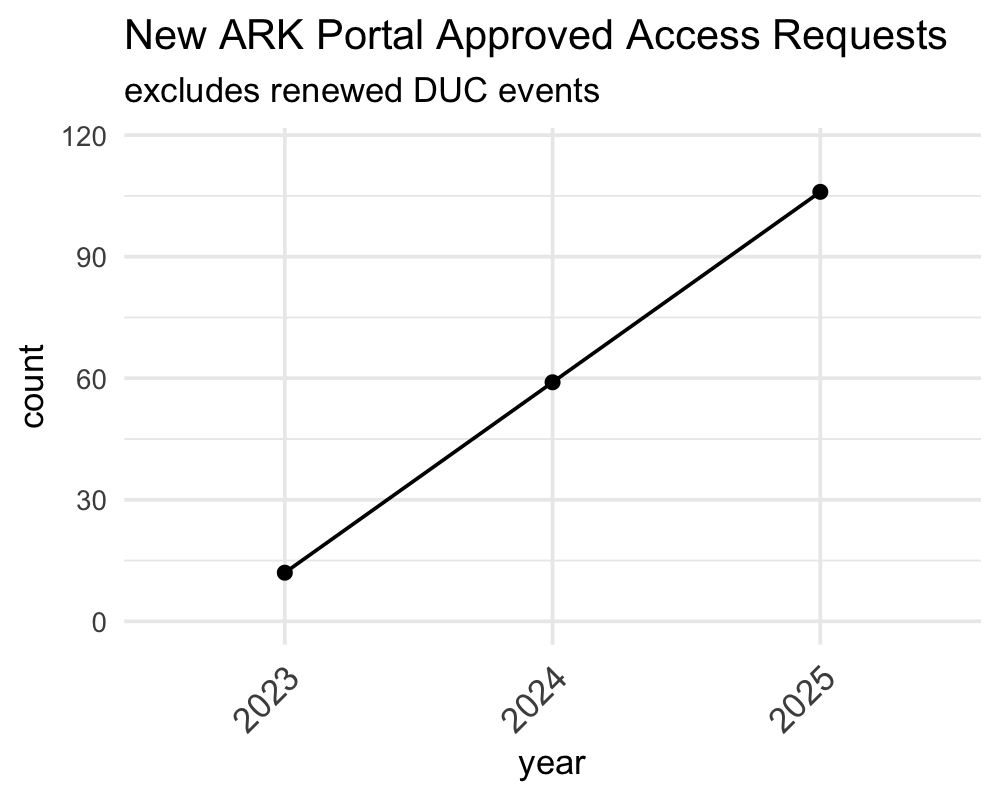

```r
knitr::include_graphics(fid)
```

# Renewals

```r
fid <- "../all_approved_requests.csv"
all_approved <- read.csv(fid, check.names = FALSE)
# assess renewed DUCs
renewed_DUC <- group_by(all_approved, `Project Lead`, Institution) %>%
  tidyr::nest()
test <- unlist(lapply(renewed_DUC$data, nrow))
idx <- which(test > 1)
renewed_DUC <- renewed_DUC[idx, ]
renewed_DUC <- tidyr::unnest(renewed_DUC, cols = c(data))
```

# Session Details

```r
#Print out session info
R.utils::System$getHostname();
```

```
nodename
```

“w255.local”

R version 4.3.3 (2024-02-29) Platform: aarch64-apple-darwin20 (64-bit) Running under: macOS Sonoma 14.7.3

Matrix products: default BLAS: /Library/Frameworks/R.framework/Versions/4.3-arm64/Resources/lib/libRblas.0.dylib LAPACK: /Library/Frameworks/R.framework/Versions/4.3-arm64/Resources/lib/libRlapack.dylib; LAPACK version 3.11.0

locale: [1] en_US.UTF-8/en_US.UTF-8/en_US.UTF-8/C/en_US.UTF-8/en_US.UTF-8

time zone: America/Chicago tzcode source: internal

attached base packages: [1] stats graphics grDevices utils datasets methods base

other attached packages: [1] glue_1.8.0 lubridate_1.9.4 ggplot2_3.5.2 stringr_1.5.1  
[5] dplyr_1.1.4

loaded via a namespace (and not attached): [1] sass_0.4.10 generics_0.1.4 tidyr_1.3.1 xml2_1.3.8  
[5] stringi_1.8.7 digest_0.6.37 magrittr_2.0.3 evaluate_1.0.4  
[9] grid_4.3.3 timechange_0.3.0 RColorBrewer_1.1-3 fastmap_1.2.0  
[13] R.oo_1.27.1 jsonlite_2.0.0 R.utils_2.13.0 httr_1.4.7  
[17] purrr_1.0.4 viridisLite_0.4.2 scales_1.4.0 textshaping_1.0.1 [21] jquerylib_0.1.4 cli_3.6.5 rlang_1.1.6 R.methodsS3_1.8.2 [25] withr_3.0.2 cachem_1.1.0 yaml_2.3.10 tools_4.3.3  
[29] kableExtra_1.4.0 vctrs_0.6.5 R6_2.6.1 png_0.1-8  
[33] lifecycle_1.0.4 pkgconfig_2.0.3 pillar_1.10.2 bslib_0.9.0  
[37] gtable_0.3.6 systemfonts_1.2.3 xfun_0.52 tibble_3.3.0  
[41] tidyselect_1.2.1 rstudioapi_0.17.1 knitr_1.50 dichromat_2.0-0.1 [45] farver_2.1.2 htmltools_0.5.8.1 rmarkdown_2.29 svglite_2.2.1  
[49] labeling_0.4.3 compiler_4.3.3